# Phase Estimation

writer : Yuseong Jeon

date: 20230613

## 1 Introduction

Phase estimation algorithm is one of the algorithm based on Quantum Fourier Transform, that is base of many other algorithms such as order finding, factoring algorithms. This algorithm is constructed with two register. First one’s qubit is initialized to be $\ket +$ ($\ket+=\frac 1{\sqrt 2}(\ket0+\ket1)$, and second one’s total state is being $U^{2^j}$’s eigen vector $\ket u$ which gets eigen value as $e^{2\pi i2^j\phi}$. The algorithm estimates total state of t qubits on first register which each qubit’s state has been rotated about z axis by controlled-$U^{2^j}$ which takes controll qubit as it self and target as second register’s total qubit. The estimation is processed by inverse QFT, link our state to $\phi$.

## 2 Construction

Construction of the algorithm is take three steps.

First, initialize the first register’s qubit to $\ket0$state, and ready the second register’s total state to $\ket u$. If we can’t initialize our second register’s state as $\ket u$, set it as nearest state $\ket\psi=\sum_uc_u\ket u$. Then $|c_u|^2$ will probability of getting $\ket u$, so we can estimate the state quite accurate.

So, at the end, we will get the state like this.

$$\begin{align*}
&\frac 1{2^{t/2}}(\ket 0+e^{2\pi i2^{t-1}\phi}\ket 1)(\ket 0+e^{2\pi
i2^{t-2}\phi}\ket 1)\cdots(\ket 0+e^{2\pi i2^{0}\phi}\ket
1)\\&=\frac 1{2^{t/2}}\sum_{k=0}^{2^t-1}e^{2\pi i\phi k}\ket k\tag2
\end{align*}$$

The circuit for our second step will be like figure under.

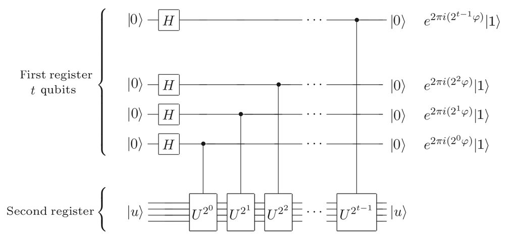

## 3 Performance and requirements

When our $\phi$ satisfies $2^{-n}\geq\phi\geq0$, and if we want to assume $\phi$ to $2^{-n}$ which get b as a value when we get t qubit that satisfies $t=n+p$, we can calculate probability of failure. Before that, our state will follow state under, when our state before been transformed.

$$QFT^\dagger(\frac 1{2^{t/2}}\sum_{k=0}^{2^t-1}e^{2\pi i\phi k}\ket
k)=\sum_{l=0}^{2^t-1}\frac 1{2^{t/2}}\sum_{k=0}^{2^t-1}e^{2\pi
i(\phi-l/2^t) k}\ket l\tag3$$

Then we can say that the probability amplitude of the state $\ket {(b+l)mod2^t}$ as,

$$a_l\equiv\frac 1{2^{t/2}}\sum_{k=0}^{2^t-1}e^{2\pi i(\phi-(b+l)/2^t)
k}\tag4$$

In this expression, b’s definition is $b+\delta2^n=2^n\phi$. b can be understand as nearest integer to $2^n\phi$, $\delta$ is binary fraction difference between $\phi$ and b. So we can say $b2^{-n}=\phi-\delta$. Then our $a_l$ is represented as,

$$a_l\equiv\frac 1{2^{t/2}}\sum_{k=0}^{2^t-1}e^{2\pi i(\phi-(b+l)/2^t)
k}=\frac 1{2^{t/2}}\sum_{k=0}^{2^t-1}e^{2\pi i(\delta-l/2^t)
k}=\frac1{2^{t/2}}\frac{1-e^{2\pi i (\delta2^t-l)}}{1-e^{2\pi
i(\delta-l/2^t)}}\tag5$$

After this, we can calculate the probability to fail when we set the failure range as $\epsilon$. And when we say m as measured state for real, then we can reproduce the range of $l$. For $m>b$, $m-b>\epsilon\rightarrow m-b=l\geq\epsilon+1$, for $m<b,m-b=l\leq-\epsilon-1$, $-2^{t-1}\leq l\leq2^{t-1}$. Probability to fail is represented as,

$$\begin{align}P(|m-b|\ge\epsilon)&=\sum_{-2^{t-1}<
l\leq-\epsilon-1}|a_l|^2+\sum_{e+1\leq l\leq
2^{t-1}}|a_l|^2\\&\leq\frac14[\sum_{-2^{t-1}<
l\leq-\epsilon-1}\frac1{l^2}+\sum_{e+1\leq l\leq
2^{t-1}}\frac1{(l-1)^2}]\\&\leq\frac12\int_{e-1}^{2^{t-1}-1}dl\frac1{l^2}=\frac1{2(e-1)}.\end{align}\tag6$$

Then we can say probability to success as $P(|m-b|\leq\epsilon)$. By our wanting to assume $\phi$ to $2^{-n}$, our $\epsilon$ is $2^{t-n}-1=2^p-1$, so probability of success will be

$$P(|m-b|\leq\epsilon)\geq1-\frac1{2(2^p-2)}\tag7$$

So if we set n and $\epsilon$, our t will be

$$t=n+under(log(2+\frac1{2\epsilon}))\tag8$$

reference. Quantum Computation and Quantum Information, Nielson&chuang

To main page